# NHANES 2017–2018 潜在剖面分析报告

R Medical Statistics Skills / sub-agent workflow

2026-07-22

# 1 研究目的

使用 NHANES 2017–2018 成人体检数据中的 BMI、腰围和平均收缩压，探索是否存在具有不同心代谢指标组合的经验性潜在剖面。

本报告复现子 agent 的独立分析过程。剖面是未加权、样本内的探索性结果，不代表美国总体估计，也不是经过验证的临床亚型。

# 2 数据与样本

原始数据来自 [CDC/NCHS NHANES 2017–2018](https://wwwn.cdc.gov/nchs/nhanes/continuousnhanes/default.aspx?BeginYear=2017)，通过 `SEQN` 合并。分析限制为 MEC 检查成人（`RIDSTATR == 2` 且 `RIDAGEYR >= 20`），普通 `mclust` 要求三个指标均有观测值，因此采用完整病例，不进行插补。

```r
data.frame(
  metric = c("Complete adult cases", "Number of variables", "Number of selected profiles"),
  value = c(nrow(analysis_data), 3, sum(model_selection$selected))
) %>%
  knitr::kable(caption = "Analysis summary")
```

Analysis summary

[output not shown]

```r
profile_means %>%
  select(indicator_label, unit) %>%
  distinct() %>%
  knitr::kable(caption = "Continuous indicators")
```

Continuous indicators

| indicator_label | unit |
| --- | --- |
| Body mass index | kg/m^2 |
| Waist circumference | cm |
| Mean systolic blood pressure | mmHg |

# 3 统计方法

对 BMI、腰围和平均收缩压进行 Z 标准化，比较 `G=1–4` 与 `EEI`、`VVI`、`EEE` 三种协方差结构。使用 `mclust` 高斯有限混合模型；其 BIC 按 `2 logLik - p log(n)` 计算，因此数值越大表示相对拟合越好。类别选择同时考虑类别规模、平均最大后验概率和分类不确定性。

NHANES 权重 `WTMEC2YR`、PSU 和分层变量保留在派生数据中，但普通 `Mclust()` 未使用复杂抽样设计。

# 4 模型选择

```r
model_selection %>%
  select(G, model, BIC, SABIC, ICL, min_class_n, min_class_prop,
         avg_max_posterior, uncertain_lt_0_70, quality_ok, selected) %>%
  head(12) %>%
  knitr::kable(digits = 3, caption = "Candidate model comparison")
```

Candidate model comparison

| G | model | BIC | SABIC | ICL | min_class_n | min_class_prop | avg_max_posterior | uncertain_lt_0_70 | quality_ok | selected |
| --- | --- | --- | --- | --- | --- | --- | --- | --- | --- | --- |
| 4 | EEE | -30696.92 | -30630.19 | -34119.35 | 262 | 0.055 | 0.856 | 0.180 | TRUE | TRUE |
| 3 | EEE | -30752.85 | -30698.83 | -32082.67 | 265 | 0.056 | 0.945 | 0.065 | TRUE | FALSE |
| 2 | EEE | -31649.27 | -31607.96 | -32674.97 | 482 | 0.101 | 0.956 | 0.050 | TRUE | FALSE |
| 1 | EEE | -32264.24 | -32235.64 | -32264.24 | 4754 | 1.000 | 1.000 | 0.000 | FALSE | FALSE |
| 4 | VVI | -32626.07 | -32540.27 | -34846.44 | 689 | 0.145 | 0.904 | 0.114 | TRUE | FALSE |
| 3 | VVI | -34186.73 | -34123.17 | -36209.16 | 1111 | 0.234 | 0.912 | 0.104 | TRUE | FALSE |
| 4 | EEI | -34603.23 | -34546.03 | -37010.82 | 286 | 0.060 | 0.897 | 0.134 | TRUE | FALSE |
| 3 | EEI | -34966.31 | -34921.82 | -36841.12 | 501 | 0.105 | 0.916 | 0.099 | TRUE | FALSE |
| 2 | VVI | -36619.89 | -36578.58 | -38232.93 | 1865 | 0.392 | 0.929 | 0.085 | TRUE | FALSE |
| 2 | EEI | -37104.82 | -37073.04 | -38377.70 | 1261 | 0.265 | 0.943 | 0.070 | TRUE | FALSE |
| 1 | EEI | -40521.60 | -40502.54 | -40521.60 | 4754 | 1.000 | 1.000 | 0.000 | FALSE | FALSE |
| 1 | VVI | -40521.60 | -40502.54 | -40521.60 | 4754 | 1.000 | 1.000 | 0.000 | FALSE | FALSE |

本次分析选择 `G=4, EEE`。选择结果应视为探索性结果；还需要在独立样本、不同缺失处理和调查设计敏感性分析中验证。

# 5 剖面规模与分类质量

```r
class_sizes %>%
  knitr::kable(digits = 3, caption = "Class sizes and posterior classification quality")
```

Class sizes and posterior classification quality

| profile | label | n | proportion | average_assigned_posterior | n_below_0_70 |
| --- | --- | --- | --- | --- | --- |
| 1 | Profile 1 | 430 | 0.090 | 0.714 | 210 |
| 2 | Profile 2 | 400 | 0.084 | 0.836 | 102 |
| 3 | Lower cardiometabolic burden | 3662 | 0.770 | 0.875 | 484 |
| 4 | Higher cardiometabolic burden | 262 | 0.055 | 0.856 | 60 |

平均最大后验概率为 0.856；最大后验概率低于 0.70 的受试者保留在分析中，不通过删除边界个体来人为提高分类清晰度。

```r
profile_means %>%
  select(label, indicator_label, unit, mean, n_hard_class) %>%
  knitr::kable(digits = 3, caption = "Original-scale hard-class profile means")
```

Original-scale hard-class profile means

| label | indicator_label | unit | mean | n_hard_class |
| --- | --- | --- | --- | --- |
| Profile 1 | Body mass index | kg/m^2 | 37.988 | 430 |
| Profile 1 | Waist circumference | cm | 128.018 | 430 |
| Profile 1 | Mean systolic blood pressure | mmHg | 122.641 | 430 |
| Profile 2 | Body mass index | kg/m^2 | 27.451 | 400 |
| Profile 2 | Waist circumference | cm | 97.255 | 400 |
| Profile 2 | Mean systolic blood pressure | mmHg | 169.251 | 400 |
| Lower cardiometabolic burden | Body mass index | kg/m^2 | 27.774 | 3662 |
| Lower cardiometabolic burden | Waist circumference | cm | 96.055 | 3662 |
| Lower cardiometabolic burden | Mean systolic blood pressure | mmHg | 122.460 | 3662 |
| Higher cardiometabolic burden | Body mass index | kg/m^2 | 46.690 | 262 |
| Higher cardiometabolic burden | Waist circumference | cm | 126.956 | 262 |
| Higher cardiometabolic burden | Mean systolic blood pressure | mmHg | 128.431 | 262 |

# 6 标准化剖面图

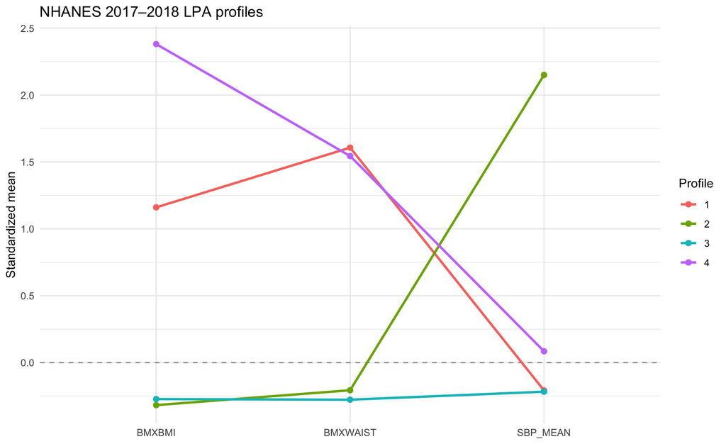

Standardized model-estimated profile means.

# 7 结果解释与限制

- 结果识别的是当前样本中的连续指标组合，不应直接命名为疾病亚型。
- 完整病例会改变目标人群；缺失可能与健康状态或检查行为有关。
- 普通 `mclust` 未处理 NHANES 复杂抽样权重、PSU 和分层，因此不能作全国代表性推断。
- 三个定义剖面的指标不应再作为独立外部验证变量；后续协变量或结局分析应传播分类不确定性。
- 横断面数据不支持时间转变或因果解释。

# 8 可复现入口

纯 R 脚本：`analysis/agent_lpa_analysis.R`；本次交付的 R Markdown 报告：`analysis/nhanes_lpa_report.Rmd`。从仓库根目录渲染本报告：

```r
rmarkdown::render(
  "example/nhanes-lpa/analysis/nhanes_lpa_report.Rmd",
  output_dir = "example/nhanes-lpa/results",
  knit_root_dir = getwd()
)
```